# SEV_PlantBiomassRegressions_Climate Effects

AJ

2017-09-28 09:54:15

## Background

Several long-term studies at the Sevilleta LTER measure net primary production (NPP) across ecosystems and treatments. Net primary production is a fundamental ecological variable that quantifies rates of carbon consumption and fixation. Estimates of NPP are important in understanding energy flow at a community level as well as spatial and temporal responses to a range of ecological processes. Above-ground net primary production (ANPP) is the change in plant biomass, including loss to death and decomposition, over a given period of time. To measure this change, vegetation variables, including species composition and the cover and height of individuals, are sampled up to three times yearly (winter, spring, and fall) at permanent plots within a study site. Sevilleta LTER dataset 157 includes cover, height, and dry biomass measurements obtained through destructive harvesting. These species are always harvested from habitat comparable to the plots in which they were recorded.

## Purpose

The following R code utilizes volume (cover x height) and weight data from Sev dataset 157 to create regressions which can be used to estimate seasonal biomass for plant species across the Sevilleta.

An initial round of analyses were done using Year, Season, Site, and Treatment as factor-type covariates when exploring the Volume:Biomass relationship. All four factors were found to significantly interact with Volume in many species. To further explore how these factors affect Volume:Biomass regressions, we are incorporating meteorological data in place of the “Year” factor.

### Step 1: Preparing the data

SEV dataset 157 (version 20161218) is used here.

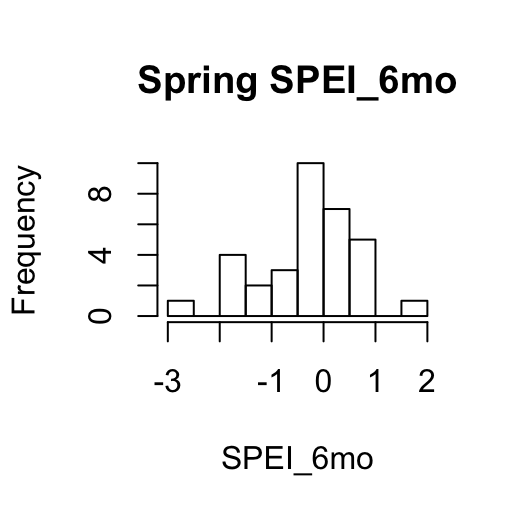

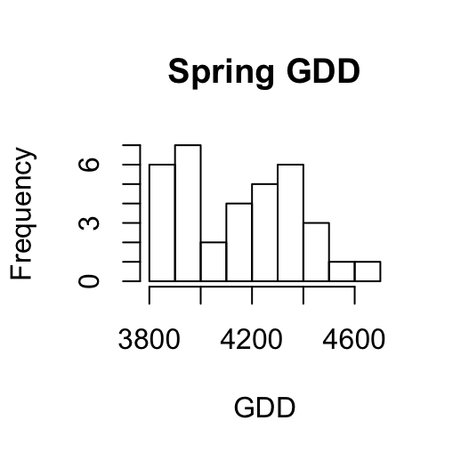

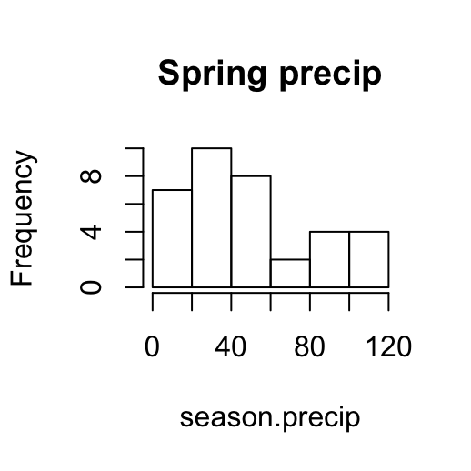

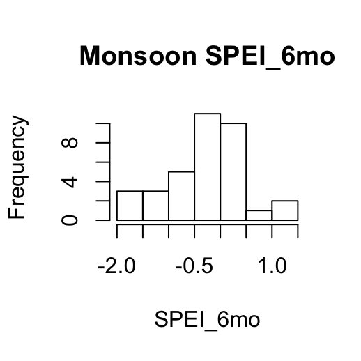

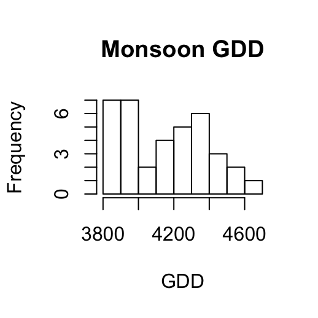

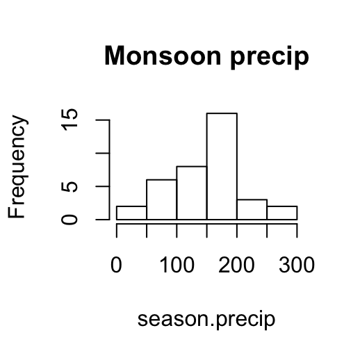

The data look like this:

| Year | MetStation | Season | SPEI_6mo | GDD | season.precip | Date | Site | Treatment | kartez | Cover | Height | Live_Weight | Volume | SiteCluster | SinceBurn | z.SPEI | z.GDD | z.precip |
| --- | --- | --- | --- | --- | --- | --- | --- | --- | --- | --- | --- | --- | --- | --- | --- | --- | --- | --- |
| 1999 | 40 | 2 | 0.5860778 | 4088.5 | 35.1 | 6/4/1999 | C | C | GUSA2 | 0.10 | 9 | 0.66 | 0.90 | L | 19 | 0.948111 | -0.2608093 | -0.4061883 |
| 1999 | 40 | 2 | 0.5860778 | 4088.5 | 35.1 | 6/4/1999 | C | C | PLJA | 0.05 | 2 | 0.01 | 0.10 | L | 19 | 0.948111 | -0.2608093 | -0.4061883 |
| 1999 | 40 | 2 | 0.5860778 | 4088.5 | 35.1 | 6/4/1999 | C | C | SCBR2 | 1.00 | 8 | 0.17 | 8.00 | L | 19 | 0.948111 | -0.2608093 | -0.4061883 |
| 1999 | 40 | 2 | 0.5860778 | 4088.5 | 35.1 | 6/9/1999 | G | C | DAPU7 | 0.05 | 1 | 0.10 | 0.05 | L | 19 | 0.948111 | -0.2608093 | -0.4061883 |
| 1999 | 40 | 2 | 0.5860778 | 4088.5 | 35.1 | 6/4/1999 | C | C | MUAR2 | 0.10 | 4 | 0.01 | 0.40 | L | 19 | 0.948111 | -0.2608093 | -0.4061883 |
| 1999 | 40 | 2 | 0.5860778 | 4088.5 | 35.1 | 6/9/1999 | G | C | ATCA2 | 2.00 | 30 | 14.36 | 60.00 | L | 19 | 0.948111 | -0.2608093 | -0.4061883 |

```r
# Create full matrix for model output
model.coefs.all <- data.frame(
  kartez = as.factor(NA),
  Year = as.factor(NA),
  Season = as.factor(NA),
  Beta.Volume = NA,
  SE = NA,
  p.value = NA,
  AdjR = NA)
```

We will consider the following species:

### Species: BOBA2

#### Season: 3

Number of observations: 103  
Sites: C G B P L  
Years collected: 1999 2002 2003 2004 2011 2013 2014  
*Size range*:  
- Cover: 0.01 - 10  
- Height: 1 - 28  
- Volume: 0.01 - 230  
- Weight: 0.01 - 8.89

### Species: BOCU

#### Season: 2

Number of observations: 100  
Sites: J P  
Years collected: 1999 2000 2003 2010 2013  
*Size range*:  
- Cover: 0.01 - 8  
- Height: 2 - 42  
- Volume: 0.02 - 252  
- Weight: 0.01 - 29.38

### Species: BOCU

#### Season: 3

Number of observations: 214  
Sites: J P  
Years collected: 1999 2000 2003 2004 2005 2006 2007 2009 2010 2011 2012 2013 2014 2015  
*Size range*:  
- Cover: 0.01 - 11  
- Height: 3 - 60  
- Volume: 0.03 - 495  
- Weight: 0.01 - 65.34

### Species: BOER4

#### Season: 2

Number of observations: 464  
Sites: G C P J B CG L  
Years collected: 1999 2000 2002 2003 2004 2005 2006 2007 2008 2010 2011 2012 2013 2014 2015 2016  
*Size range*:  
- Cover: 0.01 - 20  
- Height: 1 - 29  
- Volume: 0.01 - 580  
- Weight: 0.01 - 85.19

### Species: BOER4

#### Season: 3

Number of observations: 577  
Sites: G C P J B CG L PJ  
Years collected: 1999 2000 2002 2003 2004 2005 2006 2007 2008 2009 2010 2011 2012 2013 2014 2015 2016  
*Size range*:  
- Cover: 0.01 - 30  
- Height: 1 - 39  
- Volume: 0.02 - 1140  
- Weight: 0.01 - 122.71

### Species: BOGR2

#### Season: 2

Number of observations: 420  
Sites: G P J B L PJ  
Years collected: 1999 2000 2002 2003 2004 2005 2006 2008 2009 2010 2011 2012 2013 2014 2015 2016  
*Size range*:  
- Cover: 0.01 - 15  
- Height: 1 - 27  
- Volume: 0.01 - 390  
- Weight: 0.01 - 75.35

### Species: BOGR2

#### Season: 3

Number of observations: 495  
Sites: J P G B L  
Years collected: 1999 2000 2002 2003 2004 2005 2006 2007 2008 2009 2010 2011 2012 2013 2014 2015 2016  
*Size range*:  
- Cover: 0.01 - 30  
- Height: 1 - 47  
- Volume: 0.01 - 870  
- Weight: 0.01 - 80.35

### Species: BOHI2

#### Season: 2

Number of observations: 149  
Sites: P J  
Years collected: 1999 2000 2003 2004 2005 2006 2008 2009 2010  
*Size range*:  
- Cover: 0.01 - 10  
- Height: 1 - 15  
- Volume: 0.01 - 120  
- Weight: 0.01 - 10.57

### Species: BOHI2

#### Season: 3

Number of observations: 189  
Sites: P J  
Years collected: 1999 2000 2003 2004 2005 2006 2007 2008 2009 2010 2011 2012 2013  
*Size range*:  
- Cover: 0.01 - 5  
- Height: 1 - 34  
- Volume: 0.01 - 170  
- Weight: 0.01 - 11.17